# Kariyer.net sitesi üzerinden çekilen ‘istatistik’ anahtar kelimeli ilanların analiz edilmesi

Fatih Ekici

# Giriş

Kariyer.net üzerindeki ilanları python üzerinde selenium kütüphanesi ile çektik.Daha sonrasında excel üzerinden el ile veri analitiği ile alakasız veya istatistik mezunlarının girme şansı olmayan/girmek istemeyeceği ilanları düşürdük.Toplam veri sayısı 717 den 498 adet ilana düşürülmüştür. Bu işlemin yapılma sebebi +400 adet olan eşsiz pozisyon isimlerini daha kolay bir biçimde üst gruplara alabilmek ve daha tutarlı sonuçlar elde etmektir.

Buna ek olarak **pozisyon kısa** adı altında ilanlar belirli başlı niteliklere göre gruplandırılmıştır.

1. veri analisti(iş zekası, veri analitiği, veri bilimci ,dijital reklamcılık sektör veya tittlelarına aitilanlar)
2. finans analisti(finans sektörü hakkında bilgi gerektiren analist pozisyonları)
3. develoaper(herhangi bir sektörde yazılım-it-bilgi işlem tarafındaki pozisyonlar
4. iş analisti(finans analistine benzer şekilde genel anlamda yapılan iş ile alakalı analist pozisyonuna sahip pozisyonlar)
5. insan kaynaklari (çoğunlukla ik işleri olmak üzere az sayıda personel ile ilgilenen pozisyonlar
6. ticaret uzmanı(çoğunlukla evrak işleri, ithalat, ihracat ve satış pozisyonlarında uzmanlık gösteren pozisyonlar)
7. Muhasebe

Bazı ilanlar pek çok pozisyona yakın davranmasından dolayı en yakın seçenek tercih edilmiştir.

# Tanımlayıcı bilgiler

```r
library(readr)
library(readxl)
library(tm)
library(htmltools)
library("gridExtra")
library(tidyverse)
library(arsenal)
library("cowplot")
```

```r
mainDF <- read_excel("mainDF.xlsx")
mainDF<-unique(mainDF)
```

## Kaç farklı pozisyon vardır ve en çok tekrar edenler hangileridir?

Toplam 395 adet essiz isimli pozisyon bulunmaktadir.

```r
mainDF %>%
  group_by(pozisyon) %>%
  summarise(frekans=n()) %>%
  arrange(-frekans) %>%
  slice(1:10) %>%
  kableExtra::kable()
```

| pozisyon | frekans |
| --- | --- |
| İş Analisti | 14 |
| İş Zekası Uzmanı | 8 |
| Satın Alma Uzmanı | 8 |
| Bütçe ve Raporlama Uzmanı | 6 |
| CRM Uzmanı | 6 |
| Analiz ve Raporlama Uzmanı | 5 |
| İnsan Kaynakları Uzmanı | 5 |
| Raporlama Uzmanı | 5 |
| Veri Analisti | 5 |
| E-Ticaret Uzmanı | 4 |

```r
NA
```

Görüldüğü gibi frekans sayıları benzer işlerin farklı sayılarla belirtilmesi sebebiyle azdır.Kısaltılmış ilan sayılarını inceleyelim.

```r
mainDF %>%
  group_by(pozisyon_kisa) %>%
  summarise(frekans=n()) %>%
  arrange(-frekans) %>%
  rename(`indirgenmiş pozisyon`=pozisyon_kisa)%>%
  kableExtra::kable()
```

| indirgenmiş pozisyon | frekans |
| --- | --- |
| iş analisti | 140 |
| veri analisti | 138 |
| finans analisti | 90 |
| develoaper | 36 |
| Muhasebe | 33 |
| ticaret uzmanı | 32 |
| insan kaynaklari | 29 |

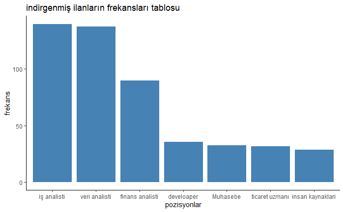

```r
mainDF %>%
  group_by(pozisyon_kisa) %>%
  summarise(frekans=n()) %>%
  arrange(-frekans) %>%
  rename(`indirgenmiş pozisyon`=pozisyon_kisa) %>%
  ###plot asamasi
  ggplot(.,aes(x=reorder(`indirgenmiş pozisyon`, -frekans),y=frekans))+
  geom_bar(stat = "identity",col='white',fill='steelblue')+
  labs(x='pozisyonlar',
  title ='indirgenmiş ilanların frekansları tablosu')+
  theme_classic()
```

```r
NA
NA
```

Beklenildiği üzere istatistik pozisyonlarında analist pozisyonların ön sıralarda olduğunu diğer meslek dallarında daha az ön planda olduğunu görmekteyiz. Finans sektörünün tek başına yüksek miktarda analist barındırdığı görülebilmektedir.

Bu kısım indirgemenin bir yan etkisi olarak net yorumlarda bulunmamızı engellemektedir. Bu sebeple sektör ve departmanları incelemek iş ilanları hakkında daha iyi bilgi sahibi olmamızı sağlar.

## Departman ve sektörel dağılım

Kariyer.net ilanlara ait sektör ve departman bilgilerini de sunmakta, bu sayede iş ilanlarının hangi sektör ve departmanda daha çok yoğunlaştığını inceleyelim.

```r
mainDF %>% group_by(`Departman:`) %>% mutate(`Departman:`=tolower(`Departman:`)) %>% summarise(frekans=n()) %>% arrange(-frekans) %>% filter(frekans>5)->freqDepartmanDF

mainDF %>%
  group_by(`Firma Sektörü:`) %>%
  mutate(`Firma Sektörü:` = tolower(`Firma Sektörü:`))  %>%
  select(`Firma Sektörü:`) %>%
  summarise(frekans = n()) %>%
  arrange(-frekans) %>%
  filter(frekans >5) ->freqSektorDF
```

```r
knitr::kable(freqDepartmanDF,
             caption = '**Departman ait frekans tablosu**')
```

**Departman ait frekans tablosu**

| Departman: | frekans |
| --- | --- |
| bilgi teknolojileri / it | 64 |
| planlama | 38 |
| finans | 35 |
| muhasebe | 28 |
| İnsan kaynakları | 27 |
| analiz / araştırma | 25 |
| satınalma | 22 |
| satış ve pazarlama | 21 |
| pazarlama | 20 |
| ar-ge | 15 |
| operasyon | 15 |
| risk yönetimi | 13 |
| İş geliştirme | 11 |
| satış | 11 |
| bilgi İşlem | 10 |
| dijital pazarlama | 10 |
| İthalat/İhracat | 8 |
| mühendislik | 8 |
| tedarik yönetimi | 7 |
| İç denetim | 6 |
| lojistik | 6 |
| teknoloji | 6 |

```r
knitr::kable(freqSektorDF,
             caption = '**Sektörlere ait frekans tablosu**')
```

**Sektörlere ait frekans tablosu**

| Firma Sektörü: | frekans |
| --- | --- |
| bankacılık | 37 |
| perakende | 35 |
| bilişim | 20 |
| sigortacılık | 18 |
| NA | 16 |
| enerji | 15 |
| üretim / endüstriyel ürünler | 13 |
| sağlık | 12 |
| diğer | 11 |
| holding / şirketler grubu | 10 |
| İlaç sanayi | 10 |
| otomotiv | 9 |
| tekstil | 9 |
| gıda | 8 |
| eğitim | 7 |
| hızlı tüketim malları | 7 |
| metal sanayi | 7 |
| bilişim, yazılım | 6 |
| çağrı merkezi ürün ve hizmetleri | 6 |
| eğitim, sağlık | 6 |
| İnşaat | 6 |

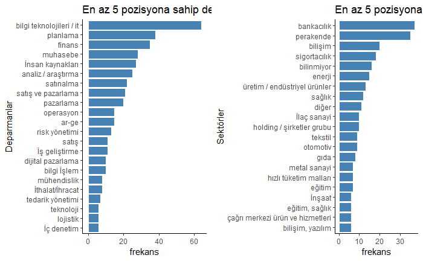

```r
mainDF %>%
  group_by(`Departman:`) %>%
  mutate(`Departman:`=tolower(`Departman:`)) %>%
  summarise(frekans=n()) %>% arrange(-frekans) %>%
  filter(frekans>5) %>%
  ggplot(.,aes(x=reorder(`Departman:`, frekans),y=frekans))+
  geom_bar(stat = "identity",col='white',fill='steelblue')+
  labs(x='Deparmanlar',title= 'En az 5 pozisyona sahip departmanlar')+
  theme_classic()+
  coord_flip()->departmanPlot

freqSektorDF %>%
  mutate(`Firma Sektörü:`=ifelse(is.na(`Firma Sektörü:`),'bilinmiyor',`Firma Sektörü:`)) %>%
  ggplot(.,aes(x=reorder(`Firma Sektörü:`, frekans),y=frekans))+
  geom_bar(stat = "identity",col='white',fill='steelblue')+
  labs(x='Sektörler',title= 'En az 5 pozisyona sahip departmanlar')+
  theme_classic()+
  coord_flip()->sektorPlot

cowplot::plot_grid(departmanPlot, sektorPlot, ncol = 2, nrow = 1)
```

Bilgi teknolojileri/it, planlama ve finans alanının en çok istihdam sağlanan departmanlardır .Sektörel anlamda ise bankacılık,perakende ve bilişim sektörü istatistik mezunlarına en çok istihdam sağlayan 3 sektördür. Bu sonuç, istatistik mezunlarının gün geçtikçe daha fazla bilgisayar ve yazılım teknolojileri ile iç içe çalıştğını göstermektedir.

Sektörel anlamda en çok istihdamın finans/bankacılık sektörü olduğu gözden kaçmamalıdır.

## iş ilanlarnın konumları

iş ilanlarının konumlarında istanbul’un avrupa ve anadolu yakaları 2 ayrı yer sayılırken kalan illerde herhangi bir değişiklik yapılmayacaktır.

Ayrıca bazı iş ilanlarında birden fazla konum olması, her bir bölgeyi ekstra sayabileceğimiz anlamına gelmektedir.Bu sebeple ilan sayısından daha fazla sayıda vilayet bulmuş oluruz.

```r
old1 <- "İ"
new1 <- "cgsıuocgsiou"
```

[output not shown]

[output cut: 19 more lines]

```r
TUR <- readRDS("TUR_adm1.rds")
TUR$NAME_1 %>% sort() %>% tolower()->TR
case_when(
   TR %in% "nevsehir"~"nevşehir",
   TR %in% "aydin"~"aydın",
   TR %in% 'eskisehir' ~ 'eskişehir',
   TR %in% 'k. maras' ~ 'kahramanmaraş',
   TR %in% 'sanliurfa' ~ 'şanlıurfa',
   TR %in% 'tekirdag' ~ 'tekirdağ',
   !(TR%in%c('eskişehir','kahramanmaraş','şanlıurfa','tekirdağ','nevşehir','aydın'))~TR

)->TR
TUR$NAME_1<-TR
```

```r
fortify(TUR) -> TUR_for
id_and_cities_ist <- data_frame(id = rownames(TUR@data),
                                'il' = TUR@data$NAME_1) %>%
  left_join(ilFreqDF, by = "il")
final_ist_map <- left_join(TUR_for, id_and_cities_ist, by = "id")
```

```r
library(mapproj)
ggplot(final_ist_map) +
  geom_polygon( aes(x = long, y = lat, group = group, fill = frekans),
                color = "grey") +
  coord_map() +
  theme_void() +
  labs(title = "2021 haziran ayı istatistik mezunlarına uygun iş ilanlarının konumları",
       subtitle = paste0("Toplam çalışılabilir konum sayisi: ", sum(ilFreqDF$frekans)),
       caption = "Veri Kaynağı: kariyer.net") +
  scale_fill_distiller(palette = 'Reds',
                       direction = 1,
                         type = "seq",
                       name = "illere göre ilan frekansı",
                       limits = c(0,400), na.value = "white") +
  theme(plot.title = element_text(hjust = 0.05),
        plot.subtitle = element_text(hjust = 0.05))
```

[output not shown]

iş ilanlarının çoğunluğu incelendiğinde ağırlıklı olarak istanbulun iş havuzunun çok yüksek bir kısmını barındırdığı görülebilir. Finans,it,arge sektörlerinin çoğunlukla istanbulda yoğunlaşması bu sonucun nihai sebebidir.

```r
gsub("İstanbul(Avr.)", "istanbul.avrupa", mainDF$city , fixed=TRUE)%>%
  gsub("İstanbul(Asya)","istanbul.asya",.,fixed =TRUE ) %>%
  gsub("İzmir","izmir",.,fixed =TRUE ) %>%
  parantezsil() %>%
  gsub(" ","",.,fixed = TRUE) %>%
  strsplit(",") %>%
  lapply(., function(x)x[!duplicated(x)]) %>%
  unlist() %>%
  gsub(" ","",.) %>%
  tolower() %>%
  table() %>%
  data.frame() %>%
  rename(il=1,frekans='Freq') %>%
  arrange(-frekans)->ilIstanbulFreqDF
ilIstanbulFreqDF[1:2,] %>% kableExtra::kable()
```

[output not shown]

Bununla beraber avrupa yakasının iş imkanı, asya yakasına göre 1,6 kat daha fazladır.Avrupa yakasında ikamet etmek iş bulma konusunda kolaylık veya avantaj sağlayabilir.

## Askerlik şartları

Askerlik durum bilgisinde yapıldı,muaf,tecilli,yapılmadı şeklinde 4 farklı kategori bulunmakta.Yapıldı ve muaf kesinlikle askere gitmeyen bir kişiyi ifade ettiği için bu 2 grubu yapıldı,tecilli ve yapılmadı ise beraber değerlendirecektir.

```r
one_hot<-function(df,col){
  dummy_list<-list(NA)
  unique(as.vector(as.matrix(df[col])))->lvls


  for(i in 1:length(lvls)){
    ifelse(as.vector(df[col]== lvls[i]),1,NA)->dummy_list[[i]]
    add_column(df, !!(lvls[i]) := dummy_list[[i]])->df
  }
  return(df)
}
```

```r
mainDF$`Askerlik Durumu:` %>% unique()
mainDF %>% select(`Askerlik Durumu:`) %>%
  mutate(`Askerlik Durumu:`=case_when(
  grepl('Yapılmadı|Tecilli',mainDF$`Askerlik Durumu:`)~'yapıldı-muaf',
  grepl('Muaf|Yapıldı',mainDF$`Askerlik Durumu:`)~'tecilli-yapılmadı',
  is.na(mainDF$`Askerlik Durumu:`)~NA_character_)) %>%
  group_by(`Askerlik Durumu:`) %>%
  summarise(`Askelik Durumu`=n()) %>%
  kableExtra::kable()
```

[output not shown]

## Tecrübe

Pozisyonlar için gerekli olan tecrübe seviyesini inceleyelim.

```r
mainDF %>% select(`Tecrübe:`,pozisyon) %>% mutate(min=case_when(
  grepl("En az",mainDF$`Tecrübe:`)~str_extract(mainDF$`Tecrübe:`,'\\d+'),
  grepl("^\\d+",mainDF$`Tecrübe:`)~str_extract(mainDF$`Tecrübe:`,'^\\d+'),
  grepl('tecrübesiz|Tecrübesiz',mainDF$`Tecrübe:`)~"0"),
  max=case_when(
    grepl("En az",mainDF$`Tecrübe:`)~NA_character_,
    grepl('En çok',mainDF$`Tecrübe:`)~str_extract(mainDF$`Tecrübe:`,'\\d+'),
  grepl("^\\d+",mainDF$`Tecrübe:`)~(str_extract_all(mainDF$`Tecrübe:`,'\\d+') %>%
    lapply(.,function(x){
  ifelse(length(x)>1,x[2],NA)}
) %>% unlist())
  )) ->tecrubeMinMaxDF
```

```r
ggplot(tecrubeMinMaxDF,aes(x=as.numeric(min)))+geom_density()+
  labs(x="Minimum Tecrübe Süresi",
       y="Yoğunluk",
       caption='Veri Kaynağı: kariyer.net\n 9eksik gozleme gore*')+
  scale_x_continuous(breaks = scales::pretty_breaks(n = 20))
```

[output not shown]

En çok aranan seviyenin mid level pozisyonlar olduğunu görülmüştür. 398 kişi yani 5 yıldan fazla tecrübeye sahip birisi ilanların ~%80’nine başvuruda bulunabilir.

```r
tecrubeMinMaxDF[grepl('müdür|yönetici|manager',tolower(tecrubeMinMaxDF$pozisyon)),] %>%
  ggplot(.,aes(x=as.numeric(min)))+geom_density()+
  labs(x="Minimum Tecrübe Süresi",
       y="Yoğunluk",
       caption='Veri Kaynağı: kariyer.net\n 9eksik gozleme gore*')+
  scale_x_continuous(breaks = scales::pretty_breaks(n = 20))
```

[output not shown]

İçerisinde **yönetici**,**müdür**,**manager** kelimelerinin geçtiği ilananlarının minimum tecrübe süresini incelendiğinde 3.yıldan itibaren yönetici pozisyonlarının yükselişe geçtiğini 5.yıldan itibaren ise zirveye yaklaştığını görmekteyiz. 5.yılın iş hayatında dikey yükseliş yaşamak için uygun bir tecrübe süresi olduğunu görebiliriz.

# ilan içeriklerinin analiz edilmesi

Bu aşamada ilan içeriklerindeki hard skill’lerin bulunması ve benzer iş ilanlarının kümelenerek bu ilanlara ait becerilerde ne tür farklılıklar/benzerlikler olduğu analiz edilecektir.